# **Electric Vehicle Charging Devices (Scotland)**

*Disclaimer: This report is intended as a proof ability to produce technical reports and visualisations using relevant data. Additional data sources and investigation is required in order to make a final estimate on the numbers of chargepoints in each Local Authority.*

# Introduction

Based on data from the [National Chargepoint Registry](https://www.gov.uk/guidance/find-and-use-data-on-public-electric-vehicle-chargepoints) the following report provides insight into the number of charging devices relative to the population size and the total number of devices in Scotland’s Local Authorities.

Data was sources from the National Chargepoint Registry in *July 2023* and the post-codes provided for each device used to map these to the appropriate Local Authority. Only exact post-code matches were accepted.

# Devices Per 100,000 of Population

[interactive chart not shown]

| <strong>Local Authority</strong> | <strong>Devices Per 100,000</strong> |
| --- | --- |
| Eilean Siar | 78 |
| Dumfries and Galloway | 77 |
| Orkney Islands | 75 |
| East Lothian | 52 |
| Shetland Islands | 52 |
| Glasgow City | 46 |
| Midlothian | 34 |
| Dundee City | 31 |
| South Lanarkshire | 30 |
| Perth and Kinross | 28 |

[output cut: 22 more lines]

- The Island regions of Scotland appear to have some of the highest number of devices per 100,000 population. However, relatively low population totals in these regions may contribute.
- Of the mainland regions, Dumfries and Galloway appear to have the highest number of charging devices per 100,000 population.

# Total Devices

[interactive chart not shown]

| <strong>Local Authority</strong> | <strong>Charging Devices</strong> |
| --- | --- |
| Glasgow City | 293 |
| Dumfries and Galloway | 116 |
| South Lanarkshire | 100 |
| Fife | 64 |
| City of Edinburgh | 61 |
| East Lothian | 57 |
| Aberdeen City | 49 |
| Dundee City | 47 |
| North Lanarkshire | 45 |
| Highland | 44 |

[output cut: 22 more lines]

- **Glasgow** has the highest overall number of charging devices; however, this is likely expected as it also has the highest total population.
- Notably, the region with the **2nd** highest number of devices is **Dumfries and Galloway** despite being ranked **13th** in population size.

# Trends Over Time

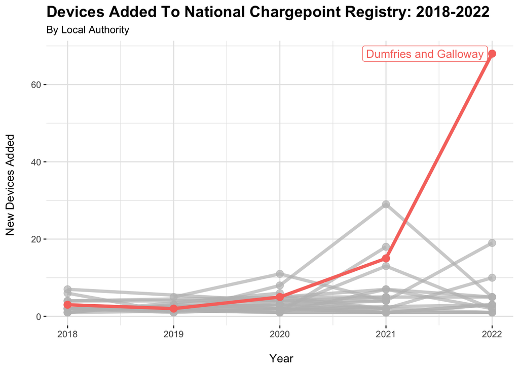

- Following the findings above, we can see that **Dumfries and Galloway** added **68** new devices in 2022. This is the largest number of new devices added by any region in one year over the last five years. The previous highest number was **29** added in Glasgow in 2021.

# Conclusions

- **Dumfries and Galloway** is notable for having a significant amount of charging devices per 100,000 population, as well as a high total number of charging devices.
- **Dumfries and Galloway** added more new devices in 2022 than any region has done in a previous year (68).
- Further work should be completed to understand the nature of the increase in new devices added in Dumfries and Galloway in 2022. For example, were these all newly installed devices, OR was there a delay in adding devices to the register from previous years? If these were all new devices, consideration should be given to the strategy and initiatives utilised.

# Data Sources

- Source: National Chargepoint Registry / Open Government Licence v3.0 / Crown Copyright 2023 https://www.gov.uk/guidance/find-and-use-data-on-public-electric-vehicle-chargepoints
- Source: National Records of Scotland: Council Area Profiles / Open Government Licence v3.0 / Crown Copyright 2023 https://www.nrscotland.gov.uk/statistics-and-data/statistics/stats-at-a-glance/council-area-profiles
- spatialdata.gov.scot / Open Government Licence v3.0 / Crown Copyright 2023 https://spatialdata.gov.scot/geonetwork/srv/api/records/1cd57ea6-8d6e-412b-a9dd-d1c89a80ad62
- doogal.co.uk / Public Domain https://www.doogal.co.uk/PostcodeDownloads